# package mycor

Keon-Woong Moon cardiomoon@gmail.com

2018-04-10

## Motivation

### For correlation analysis : `cor`, `cor.test` and `lm`

When I began to study R software, I was really impressed with the function `cor`. As you knows, the ‘cor’ function returns all `r` values of every possible pairs of matrix or data.frame provided that it consists of numeric data only. For example, `cor(mtcars[1:5])` acts just as expected.

```r
cor(mtcars[1:5])
            mpg        cyl       disp         hp       drat
mpg   1.0000000 -0.8521620 -0.8475514 -0.7761684  0.6811719
cyl  -0.8521620  1.0000000  0.9020329  0.8324475 -0.6999381
disp -0.8475514  0.9020329  1.0000000  0.7909486 -0.7102139
hp   -0.7761684  0.8324475  0.7909486  1.0000000 -0.4487591
drat  0.6811719 -0.6999381 -0.7102139 -0.4487591  1.0000000
```

But `cor(iris)` returns error because the data.frame consist of both numeric and factor variable.

```r
cor(iris)
Error in cor(iris): 'x' must be numeric
```

If you wanted to get `p` values as well as `r` values, you should use `cor.test` instead of `cor`. But `cor.test` can deal with only one pair of numeric vectors of the same length, neither a matrix nor a data.frame. Furthermore, if you wanted to get the `slope` and `intercept` of simple linear regression line of xyplot, you had to perform `lm` test for every pairs of numeric variables of the data.frame.

## Solution ; Do not repeat yourself !!

My idea is that a single function deals with data.frame of mixed numeric, logical and factor variables, select numeric variables, perform `cor.test` and `lm` to get `r`,`p`,`slope` and `intercept` of every pairs of the variables for exploratory analysis. It can save my time and effort.

## Function “mycor” and Class “mycor”

```r
require(lattice)
require(mycor)
mycor(iris)

$ r value by Pearson's product-moment correlation

             Sepal.Length Sepal.Width Petal.Length Petal.Width
Sepal.Length        1.000      -0.118        0.872       0.818
Sepal.Width        -0.118       1.000       -0.428      -0.366
Petal.Length        0.872      -0.428        1.000       0.963
Petal.Width         0.818      -0.366        0.963       1.000

$ p value ( two.sided )

             Sepal.Length Sepal.Width Petal.Length Petal.Width
Sepal.Length        0.000       0.152            0           0
Sepal.Width         0.152       0.000            0           0
Petal.Length        0.000       0.000            0           0
Petal.Width         0.000       0.000            0           0
```

The mycor function reurns an object of class “mycor”. This can be saved for print, summarize and plot. A S3 method for class `formula` can be used to function `mycor`. Function `print.mycor` shows the r values and th p values similar to the function `cor`. A `mycor` class object can be summarized with summary function, summary().

```r
out=mycor(iris,alternative="greater", method="kendall",digits=2)
out1=mycor(~mpg+disp+hp+wt,data=mtcars)
summary(out1)

$ r value by Pearson's product-moment correlation

        mpg   disp     hp     wt
mpg   1.000 -0.848 -0.776 -0.868
disp -0.848  1.000  0.791  0.888
hp   -0.776  0.791  1.000  0.659
wt   -0.868  0.888  0.659  1.000

$ p value ( two.sided )

     mpg disp hp wt
mpg    0    0  0  0
disp   0    0  0  0
hp     0    0  0  0
wt     0    0  0  0

$ slope

        mpg  disp    hp     wt
mpg    1.00 -0.04 -0.07  -5.34
disp -17.43  1.00  1.43 112.48
hp    -8.83  0.44  1.00  46.16
wt    -0.14  0.01  0.01   1.00

$ intercept

        mpg  disp    hp      wt
mpg    0.00 29.60 30.10   37.29
disp 580.88  0.00 20.99 -131.15
hp   324.08 45.73  0.00   -1.82
wt     6.05  1.60  1.84    0.00
```

The `mycor` function uses cor.test internally, so you can use all options of `cor.test` - namely `alternatives`, `method`, `conf.level`,… .

## Plot “mycor” object

Probably most valuable function is plot. It is not a new function. It uses internally one of two popular function : graphics::pairs() and lattice::parallelplot(). In fact, plot.mycor function have four types of plot : Three variants of pairs and parallelplot. Call function `plot` with no option makes pairs().

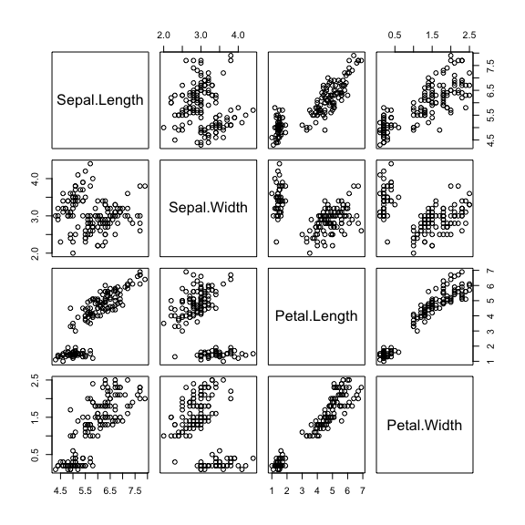

```r
plot(out)
```

But if you specify the groups, you can get more pretty plot. You can use extra arguments which can used in pairs() or parallelplot().

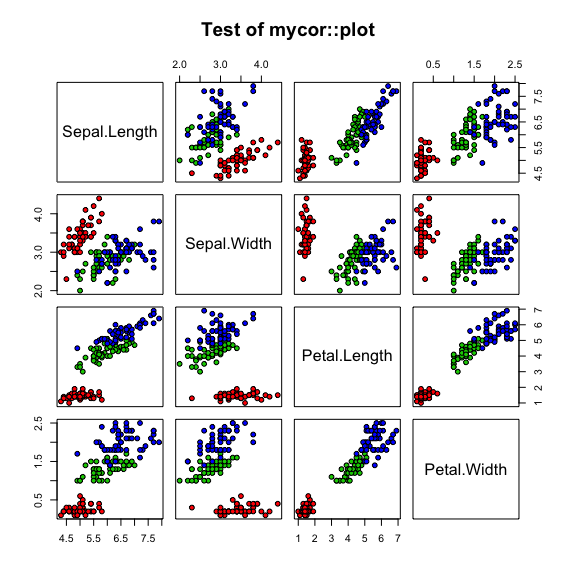

```r
plot(out,groups=species,main="Test of mycor::plot")
```

With `type=2` option, you can get histogram at diagonal panel.

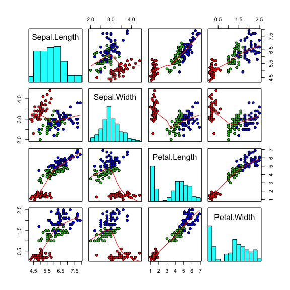

```r
plot(out,type=2,groups=spe)
```

With `type=3` option, you can get correlation plot at upper panels.

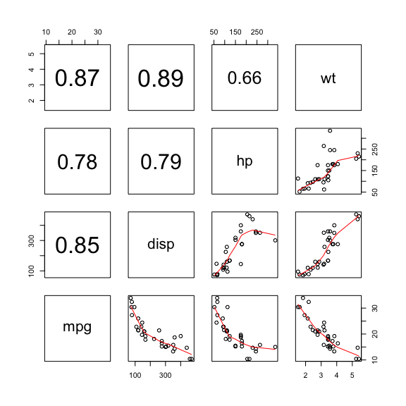

```r
plot(out1,type=3)
```

With `type=4` option, you can get parallelplot.

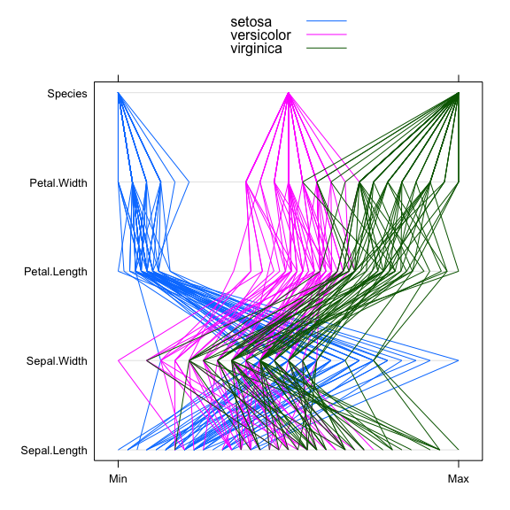

```r
plot(out,type=4,groups=spe)
```

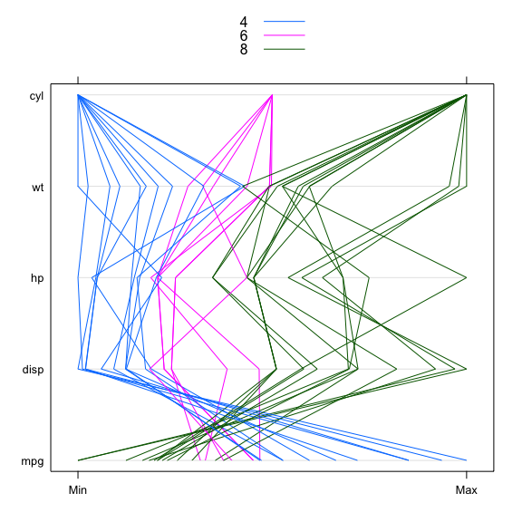

```r
plot(out1,type=4,groups=cyl)
```